### Background

Speech Reception Thresholds (in noise) using IEEE sentences.

Two groups:

- young adults without much noise exposure history
- middle-aged adults with quite a bit of noise exposure history

Four conditions (2x2):

- two stimulus levels (40 and 80 dB SPL)
- either both the target and background noise were diotic (N<sub>0</sub>S<sub>0</sub>), or the target signal was inverted in polarity in one ear (N<sub>0</sub>S<sub>$\pi$</sub>) leading to a phase disparity across the ears

### The data

uLevs = mean SNR (i.e. SRT)  
sdLevs = standard deviation SNR

```
##   listener group dBSPL manipulation     uLevs   sdLevs
## 1      M01     M    40     inverted -3.250000 2.175623
## 2      M01     M    40     inverted -3.857143 1.833750
## 3      M01     M    40         none -1.444444 2.894665
## 4      M01     M    40         none -2.000000 1.788854
## 5      M01     M    80     inverted -8.777778 3.001089
## 6      M01     M    80     inverted -8.533333 1.767430
```

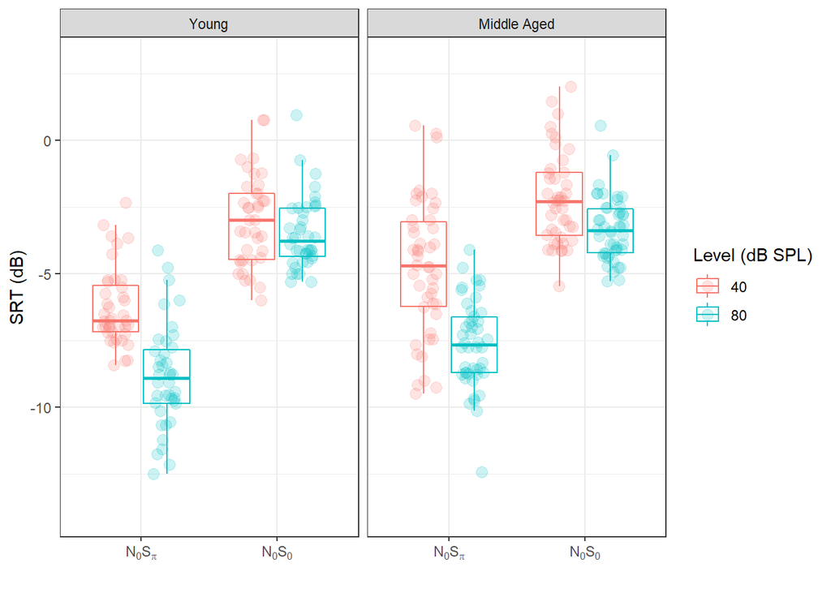

### Bayesian analysis

#### Step 1: Begin with an “empty” model with varying intercepts

Questions:

- Should I standardize the outcome measure as well as the predictors?
- How should I assess the model at this stage?

I am creating an index variable for the listener variable. Note that I am not standardizing the outcome variable, instead I will specify the priors in dB.

Based on my PhD data (IEEEs in steady-state and amplitude modulated speech-shaped noise for young and older adults), I expect the overall mean to be -5 dB and the sd to be 1.5 dB.

```r
d <- iee %>%
  mutate(uLevs = uLevs) %>%
  mutate(listener = as.numeric(listener))
```

Specify the model as follows:

SRT ~ Normal(mu, sigma)  
mu = a[listener]  
a[listener] ~ Normal(a_bar, a_sigma)  
a_bar ~ Normal(-5,1.5)  
a_sigma ~ cauchy(0,1)  
sigma ~ cauchy(0,1)

Question:

- Why would you use a half-cauchy distribution as opposed to an exponential or half-normal? I’ve heard that the cauchy distribution assumes medium-large effects, not small ones.

```r
# specify varying intercept only model
brms_fmla <- brmsformula(uLevs ~ (1 | listener))

# specify priors
priors <- c(
  set_prior("normal(-5,1.5)",  class = "Intercept"),
  set_prior("cauchy(0,1)",  class = "sd"),
  set_prior("cauchy(0,1)",  class = "sd", coef = "Intercept", group = "listener")
)

# compile and run model
prior_only.mod <- brm(
  brms_fmla,
  data = d,
  family = "gaussian",
  prior = priors,
  inits = 0,
  iter = 2000,
  warmup = 1000,
  chains = 2,
  cores = 2,
  sample_prior = "only",
  seed = 42,
  control = list(max_treedepth = 10,
                 adapt_delta = 0.8)
)

save(prior_only.mod, file = here("prior_only.RDATA"))
```

```
##  Family: gaussian
##   Links: mu = identity; sigma = identity
## Formula: uLevs ~ (1 | listener)
##    Data: d (Number of observations: 342)
## Samples: 2 chains, each with iter = 2000; warmup = 1000; thin = 1;
##          total post-warmup samples = 2000
##
## Group-Level Effects:
## ~listener (Number of levels: 42)
##               Estimate Est.Error l-95% CI u-95% CI Rhat Bulk_ESS Tail_ESS
## sd(Intercept)     8.52    100.81     0.03    27.43 1.00     2827     1192
##
## Population-Level Effects:
##           Estimate Est.Error l-95% CI u-95% CI Rhat Bulk_ESS Tail_ESS
## Intercept    -4.98      1.45    -7.80    -2.13 1.00     3994     1519
##
## Family Specific Parameters:
##       Estimate Est.Error l-95% CI u-95% CI Rhat Bulk_ESS Tail_ESS
## sigma    11.05     12.57     0.40    42.24 1.00     2408     1138
##
## Samples were drawn using sampling(NUTS). For each parameter, Eff.Sample
## is a crude measure of effective sample size, and Rhat is the potential
## scale reduction factor on split chains (at convergence, Rhat = 1).
```

Questions:

- How would I go about interpreting this?
- Would I need to look at any of this at this stage, or would I just do a prior predictive check and plot the results?

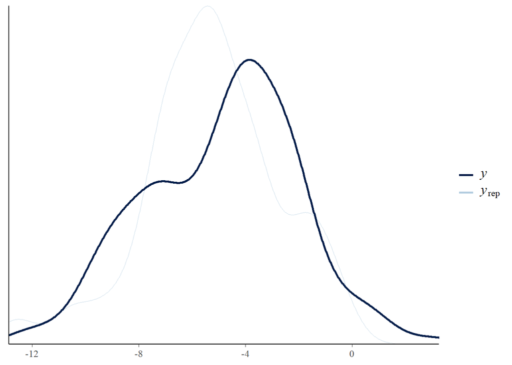

Prior predictive check: density plot showing priors (yrep) and SRTs (y).

```r
# prior predictive check
ppc_dens_overlay(y = as.vector(d$uLevs),
                 yrep = t(predict(prior_only.mod, draws=25)[,1])
                 )
```

This looks reasonable. It’s not perfect, but it’s a prior, it doesn’t need to be. The data can do the rest. At least this is in the right ballpark, suggesting I didn’t do something obviously stupid (yet).

#### Step 2: Start adding predictor variables

Let’s start building the model up a bit more by adding predictor variables. I will standardize predictors and create index variables.

Predictors:

- manipulation: the effect of inverting the polarity of the speech across the ears. The difference between the two conditions (inverted and not inverted) is the binaural intelligibility level difference (BILD)
- dBSPL: the stimulus level (40 or 80 dB SPL)
- group: young or middle-aged

Create an index variable for the ‘manipulation’ variable, where ‘none’ (i.e. not inverted) = 1, and ‘inverted’ = 2.

We will need to come up with a better estimate for the prior, based on the literature, but for now I’ll just assume an effect of ‘manipulation’ (i.e. BILD) of 3 dB with a standard deviation of 1 dB. Since 1 = none, and inverted = 2, I will use a negative mean, because SRTs are expected to decrease (i.e. improve) when the polarity of the speech is inverted in one ear.

Question:

- Should I create an index variable for the dBSPL variable (it only has two levels, so they are like ordered categories), or shall I standardize it (underlyingly it’s a continuous predictor)?

For now I have decided to create an index variable for the dBSPL predictor since there are only two levels. 40 dB SPL = 1, 80 dB SPL = 2. I’m guessing that the effect of stimulus level is going to be 3 dB, with performance improving at higher levels. Therefore, the prior has a mean of -3 dB.

I’m creating an index variable for group, where ‘young’ = 1, and ‘middle-aged’ = 2. I expect SRTs to be higher (i.e. poorer) for the middle-aged group, so I’m specifying the prior with a positive mean. I’m just guessing at this point that the effect is going to be pretty small, say 1 dB.

```r
d <- iee %>%
  mutate(listener = as.numeric(listener)) %>%
  mutate(manipulation = as.numeric(fct_rev(as.factor(manipulation))),
         dBSPL = as.numeric(dBSPL),
         group = as.numeric(group))
```

Specify the model as follows:

SRT ~ Normal(mu, sigma)  
mu = a[listener] + bM * manipulation + bdB * dBSPL + bG * group  
a[listener] ~ Normal(a_bar, a_sigma)  
a_bar ~ Normal(-5,1.5)  
a_sigma ~ cauchy(0,1)  
bM ~ Normal(-3, 1)  
bdB ~ Normal(-3, 1)  
bG ~ Normal(1, 1)  
sigma ~ cauchy(0,1)

To figure out:

- Add interactions
- Add random slopes
- Could I use measurement error (SD) for IEEEs in my model? I’ve seen something like this in the Statistical Rethinking book

```r
# specify varying intercept & manipulation effect model
brms_fmla <- brmsformula(uLevs ~ manipulation + dBSPL + group + (1 | listener))

# specify priors
priors <- c(
  set_prior("normal(-5,1.5)",  class = "Intercept"),
  set_prior("normal(-3,1)",  class = "b", coef = "manipulation"),
  set_prior("normal(-3,1)",  class = "b", coef = "dBSPL"),
  set_prior("normal(1,1)",  class = "b", coef = "group"),
  set_prior("cauchy(0,1)",  class = "sd"),
  set_prior("cauchy(0,1)",  class = "sd", coef = "Intercept", group = "listener")
)

# compile and run model
full.mod <- brm(
  brms_fmla,
  data = d,
  family = "gaussian",
  prior = priors,
  inits = 0,
  iter = 5000,
  warmup = 2000,
  chains = 4,
  cores = 4,
  sample_prior = TRUE,
  seed = 42,
  control = list(max_treedepth = 10,
                 adapt_delta = 0.8)
)

save(full.mod, file = here("fullModel.RDATA"))
```

```
##  Family: gaussian
##   Links: mu = identity; sigma = identity
## Formula: uLevs ~ manipulation + dBSPL + group + (1 | listener)
##    Data: d (Number of observations: 342)
## Samples: 4 chains, each with iter = 5000; warmup = 2000; thin = 1;
##          total post-warmup samples = 12000
##
## Group-Level Effects:
## ~listener (Number of levels: 42)
##               Estimate Est.Error l-95% CI u-95% CI Rhat Bulk_ESS Tail_ESS
## sd(Intercept)     0.86      0.14     0.61     1.17 1.00     4381     5686
##
## Population-Level Effects:
##              Estimate Est.Error l-95% CI u-95% CI Rhat Bulk_ESS Tail_ESS
## Intercept        2.21      0.63     1.00     3.43 1.00    10139     9424
## manipulation    -3.89      0.17    -4.23    -3.55 1.00    17816     9009
## dBSPL           -1.88      0.18    -2.22    -1.53 1.00    17987     8373
## group            1.01      0.30     0.41     1.61 1.00     8106     8560
##
## Family Specific Parameters:
##       Estimate Est.Error l-95% CI u-95% CI Rhat Bulk_ESS Tail_ESS
## sigma     1.63      0.07     1.51     1.77 1.00    13157     9547
##
## Samples were drawn using sampling(NUTS). For each parameter, Eff.Sample
## is a crude measure of effective sample size, and Rhat is the potential
## scale reduction factor on split chains (at convergence, Rhat = 1).
```

Questions:

- Am I interpreting this correctly?
- What’s the difference between Family specific parameters and group-level effects?
- What does the population-level intercept refer to?
- What other things should I look at in this table? Rhat looks ok.

`Group-level effects: sd(Intercept)`: remaining unexplained variability among participants? This has changed quite a bit compared to the intercept-only model. `Population-level effects`: I’m not sure what the intercept refers to here anymore. It’s not the overall mean. Presumably the others are the effects of polarity inversion (manipulation), stimulus level (dBSPL), and group.

#### Step 3: Visualize the results

Questions:

- How do I evaluate the model?
- What should I visualize?

I’m not entirely sure what to visualize exactly, so I’m just trying a few things that seem sensible.

First, let’s see what’s in this model.

```r
get_variables(full.mod)
```

```
##  [1] "b_Intercept"              "b_manipulation"
##  [3] "b_dBSPL"                  "b_group"
##  [5] "sd_listener__Intercept"   "sigma"
##  [7] "r_listener[1,Intercept]"  "r_listener[2,Intercept]"
##  [9] "r_listener[3,Intercept]"  "r_listener[4,Intercept]"
## [11] "r_listener[5,Intercept]"  "r_listener[6,Intercept]"
## [13] "r_listener[7,Intercept]"  "r_listener[8,Intercept]"
## [15] "r_listener[9,Intercept]"  "r_listener[10,Intercept]"
## [17] "r_listener[11,Intercept]" "r_listener[12,Intercept]"
## [19] "r_listener[13,Intercept]" "r_listener[14,Intercept]"
## [21] "r_listener[15,Intercept]" "r_listener[16,Intercept]"
## [23] "r_listener[17,Intercept]" "r_listener[18,Intercept]"
## [25] "r_listener[19,Intercept]" "r_listener[20,Intercept]"
## [27] "r_listener[21,Intercept]" "r_listener[22,Intercept]"
## [29] "r_listener[23,Intercept]" "r_listener[24,Intercept]"
```

[output cut: 16 more lines]

Next, let’s turn this into a sensible data frame for plotting.

Wait, I don’t think I’m actually using this data frame! What format should the data be in?

```r
full <- full.mod %>%
  spread_draws(b_Intercept, b_manipulation, b_group, b_dBSPL, r_listener[listenerID,term])

head(full)
```

```
## # A tibble: 6 x 10
## # Groups:   listenerID, term [6]
##   .chain .iteration .draw b_Intercept b_manipulation b_group b_dBSPL
##    <int>      <int> <int>       <dbl>          <dbl>   <dbl>   <dbl>
## 1      1          1     1        2.57          -3.98   0.808   -1.75
## 2      1          1     1        2.57          -3.98   0.808   -1.75
## 3      1          1     1        2.57          -3.98   0.808   -1.75
## 4      1          1     1        2.57          -3.98   0.808   -1.75
## 5      1          1     1        2.57          -3.98   0.808   -1.75
## 6      1          1     1        2.57          -3.98   0.808   -1.75
## # ... with 3 more variables: listenerID <int>, term <chr>,
## #   r_listener <dbl>
```

Let’s start with plotting the results that we looked at before in table form (the population level effects).

I’m going to start with creating a data fram that combines the data and the draws from the posterior fit.

Question:

- Is there an easy way to go from the indexed variables back to the original values?

```r
#
draws <- d %>%
  modelr::data_grid(listener, manipulation, dBSPL, group) %>%
  add_fitted_draws(full.mod) %>%
  select(-.chain, -.iteration)

head(draws)
```

```
## # A tibble: 6 x 7
## # Groups:   listener, manipulation, dBSPL, group, .row [1]
##   listener manipulation dBSPL group  .row .draw .value
##      <dbl>        <dbl> <dbl> <dbl> <int> <int>  <dbl>
## 1        1            1     1     1     1     1  -2.72
## 2        1            1     1     1     1     2  -1.92
## 3        1            1     1     1     1     3  -3.33
## 4        1            1     1     1     1     4  -1.52
## 5        1            1     1     1     1     5  -2.09
## 6        1            1     1     1     1     6  -2.47
```

Questions:

- What should I look at?
- How should I plot it? My plots can definitely be improved.
- Should I just look at the effects or also at the individuals?

’Let’s plot the posterior draws (What’s this called?) for the two groups, where 1 = young, 2 = middle-aged:

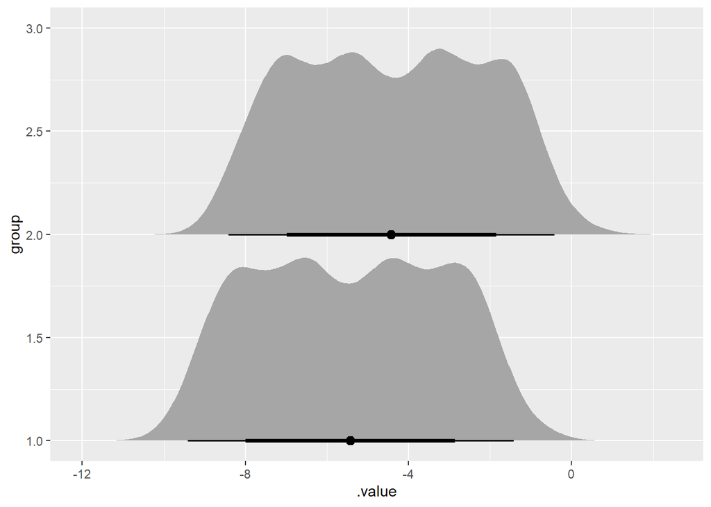

```r
draws %>%
  ggplot(aes(x = .value, y = group)) +
  stat_halfeyeh()
```

For the two manipulation conditions, where 1 = none, 2 = inverted:

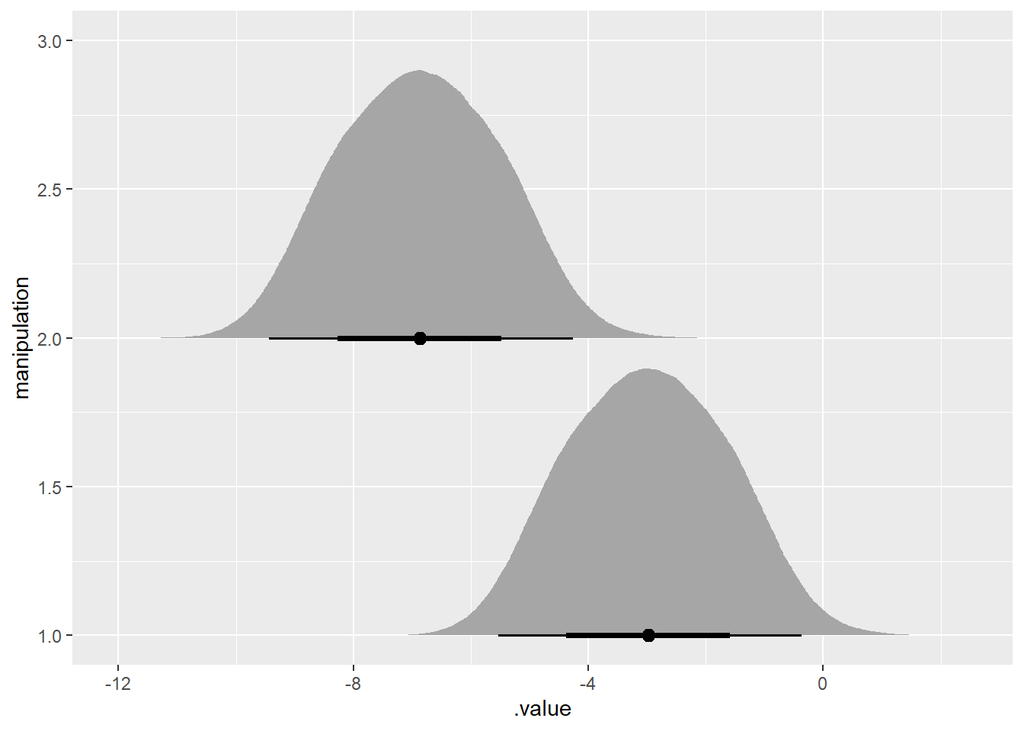

```r
draws %>%
  ggplot(aes(x = .value, y = manipulation)) +
  stat_halfeyeh()
```

Stimulus level, where 1 = 40 dB SPL, 2 = 80 dB SPL:

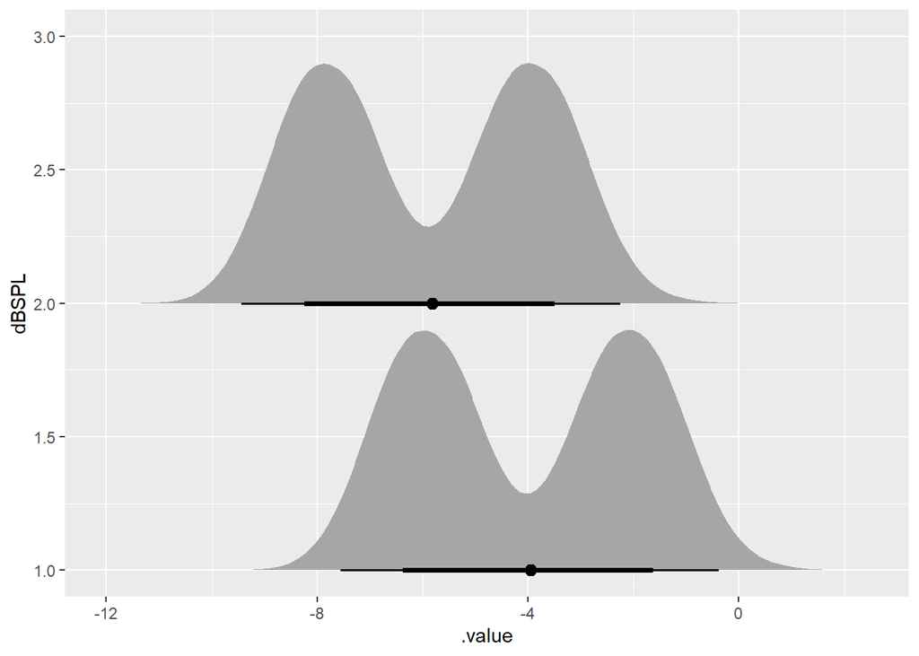

```r
draws %>%
  ggplot(aes(x = .value, y = dBSPL)) +
  stat_halfeyeh()
```

Other things I’d like to look at:

- Difference between groups, manipulations, stimulus levels. Not sure how to plot that. The data frames are a pain to manipulate for some reason.
- Whatever I need to do for a proper posterior check. Can / should I plot things with the data?

Another thing I’ve seen being plotted, but I’m not sure what it means:

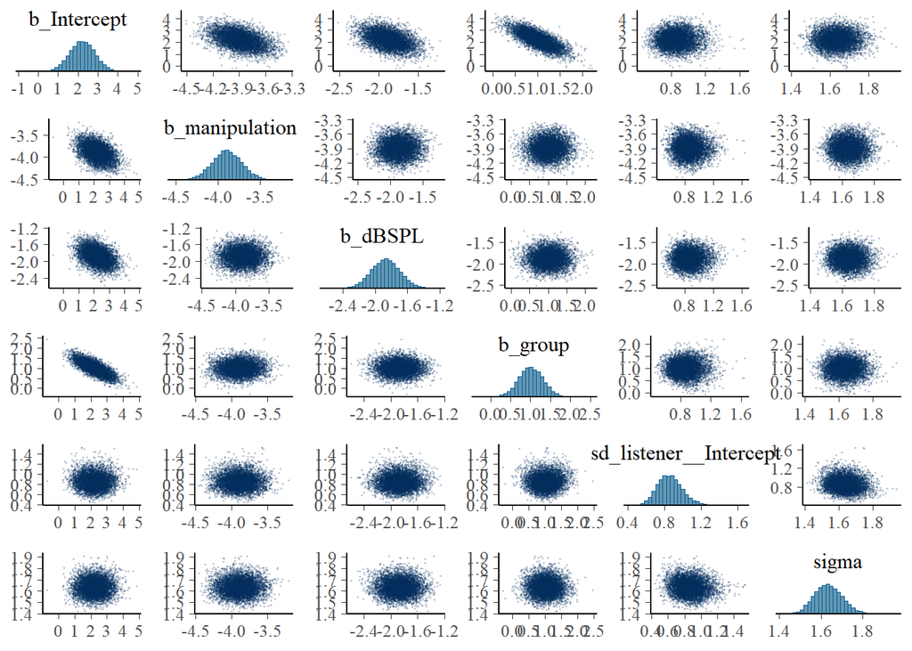

```r
pairs(full.mod,
      off_diag_args = list(size = 1/5, alpha = 1/5))
```

And I figured, let’s look at WAIC and LOO, without really knowing what to do with it:

```r
full.mod <- add_criterion(full.mod, c("waic", "loo"))

full.mod$waic
```

```
##
## Computed from 12000 by 342 log-likelihood matrix
##
##           Estimate   SE
## elpd_waic   -669.7 15.0
## p_waic        31.5  2.8
## waic        1339.5 30.0
```

```r
full.mod$loo
```

```
##
## Computed from 12000 by 342 log-likelihood matrix
##
##          Estimate   SE
## elpd_loo   -670.1 15.0
## p_loo        31.8  2.8
## looic      1340.2 30.1
## ------
## Monte Carlo SE of elpd_loo is 0.1.
##
## All Pareto k estimates are good (k < 0.5).
## See help('pareto-k-diagnostic') for details.
```

A separate question is whether the model ran correctly. Let’s visualize the chains.

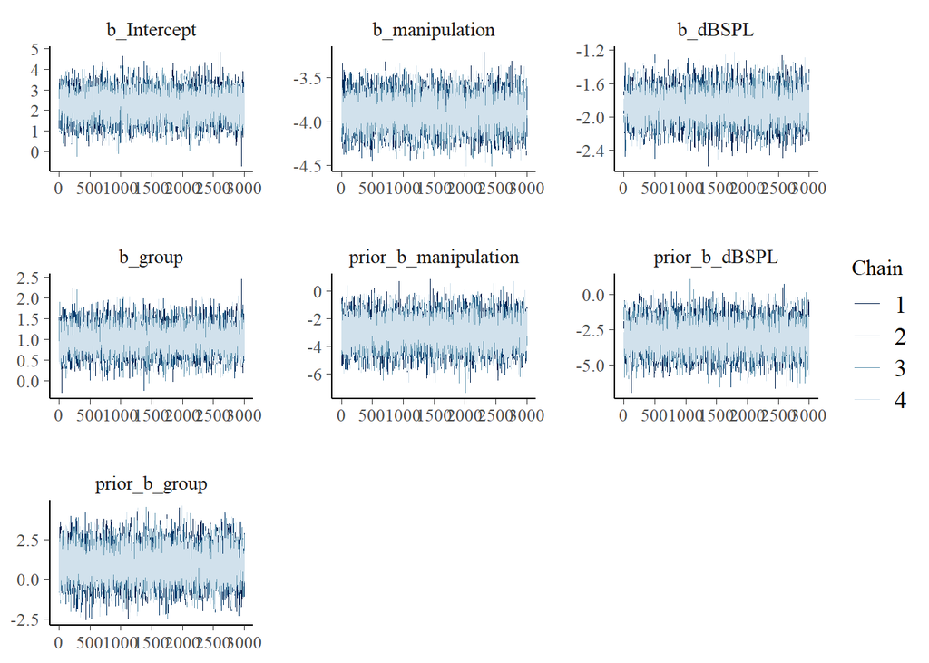

```r
# extract the posterior samples
post <- posterior_samples(full.mod, add_chain = T)
# plot the traces
mcmc_trace(post, regex_pars = "b_")
```

This looks good, nothing crazy going on.

### More questions

- Anything else I should be doing? Or something I shouldn’t be doing?
- How would I best explain the difference in inference between Bayesian and frequentist stats?
- What if you have unequal number of measures per participant, partly on purpose, because you decided to rerun a test occasionally? I think that’s fine, the multilevel model will deal with that. My collaborator wants to compute a median across multiple measurements.
- Are there fewer assumptions because you can just model things the way you want?
- What do you do with outliers? Check something in WAIC or LOO or something?
- What do you do with missing data? Bayesian imputation?